# Assignment 1 Part 1

September 25, 2015

```r
print(load(url("http://eeyore.ucdavis.edu/stat141/Data/vehicles.rda")))
```

```
## [1] "vposts"
```

```r
lty = c(3, 4, 5) #changes the line types (dotted, dashed, etc)
# ~odometer means you want odometer on the x-axis,
# how to add more than one line in a density plot

#plots multiple lines on a density plot
table(vposts$transmission)
```

```
##
## automatic    manual     other
##     28641      3800      1214
```

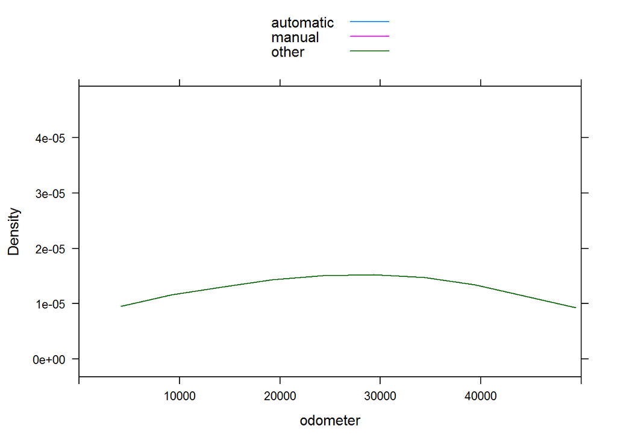

```r
library(lattice)
densityplot(~odometer, vposts, group = transmission, plot.points = FALSE, xlim = c(0, 50000), auto.key = TRUE)
```

### 1. How many observations are there in the data set?

```r
nrow(vposts)
```

```
## [1] 34677
```

There are 34677 observations in the data frame.

### 2. What are the names of the variables? and what is the class of each variable?

The names of the variables in vposts are:

```r
names(vposts)
```

```
##  [1] "id"           "title"        "body"         "lat"
##  [5] "long"         "posted"       "updated"      "drive"
##  [9] "odometer"     "type"         "header"       "condition"
## [13] "cylinders"    "fuel"         "size"         "transmission"
## [17] "byOwner"      "city"         "time"         "description"
## [21] "location"     "url"          "price"        "year"
## [25] "maker"        "makerMethod"
```

The classes are of the variables in vposts are listed below:

```r
lapply(vposts, class)
```

```
## $id
## [1] "character"
##
## $title
## [1] "character"
##
## $body
## [1] "character"
##
## $lat
## [1] "numeric"
##
## $long
## [1] "numeric"
##
## $posted
## [1] "POSIXct" "POSIXt"
##
## $updated
## [1] "POSIXct" "POSIXt"
##
## $drive
## [1] "factor"
##
## $odometer
## [1] "integer"
##
## $type
## [1] "factor"
##
## $header
## [1] "character"
##
## $condition
## [1] "factor"
##
## $cylinders
## [1] "integer"
##
## $fuel
```

[output cut: 22 more lines]

```
##
## $url
## [1] "character"
##
## $price
## [1] "integer"
##
## $year
## [1] "integer"
##
## $maker
## [1] "character"
##
## $makerMethod
## [1] "numeric"
```

### 3. What is the average price of all the vehicles? the median price? and the deciles? Displays these on a plot of the distribution of vehicle prices.

Information found on Piazza.

```r
c <- vposts$price #assign vposts$price to c
mean_price = mean(c, na.rm = TRUE) #mean
mean_price
```

```
## [1] 49449.9
```

```r
median_price = median(c, na.rm = TRUE) #median
median_price
```

```
## [1] 6700
```

```r
quant_price = quantile(c, prob = seq(0, 1, .1), na.rm = TRUE) #decile
quant_price
```

```
##        0%       10%       20%       30%       40%       50%       60%
##         1      1200      2499      3500      4995      6700      8900
##       70%       80%       90%      100%
##     11888     15490     21997 600030000
```

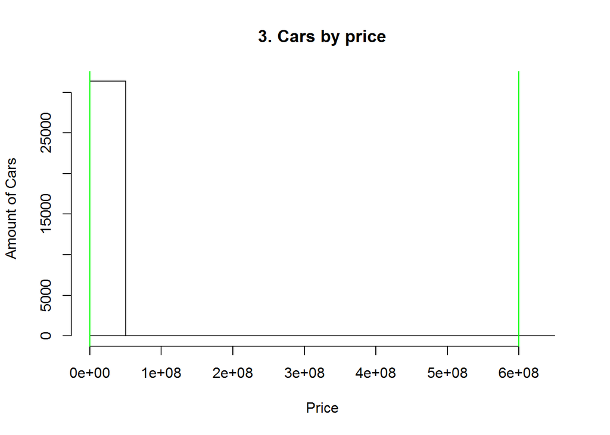

```r
hist(vposts$price, main = "3. Cars by price", xlab = "Price", ylab = "Amount of Cars")
abline(v = mean_price, col = "red") #mean is in RED
abline(v = median_price, col = "blue") #median is in BLUE
abline(v = quant_price, col = "green") #deciles are in GREEN
```

There are an extreme outliers that are skewing the distribution right. In statistics, an outlier is an observation point that is distant from other observations.

```r
head(sort(vposts$price, decreasing = TRUE)) #look for outliers
```

```
## [1] 600030000 600030000  30002500   9999999    569500    559500
```

There are 4 outliers and they are 600030000, 600030000, 30002500, and 9999999. Removing the outliers will allow me to be able to produce a graph that gives up a better representation of the data that we have.

```r
remove_outliers = subset(vposts, vposts$price < 600000) #make a subset without the outliers
c2 = remove_outliers$price #sets remove_outliers$price to c2
remove_outliers_mean = mean(c2, na.rm = TRUE) #find mean
remove_outliers_mean
```

```
## [1] 9894.478
```

```r
remove_outliers_quant = quantile(c2, prob = seq(0, 1, .1), na.rm = TRUE) #find deciles
remove_outliers_quant
```

```
##       0%      10%      20%      30%      40%      50%      60%      70%
##      1.0   1200.0   2499.0   3500.0   4995.0   6700.0   8900.0  11888.0
##      80%      90%     100%
##  15488.4  21995.0 569500.0
```

```r
remove_outliers_median = median(c2, na.rm = TRUE) #find median
remove_outliers_median
```

```
## [1] 6700
```

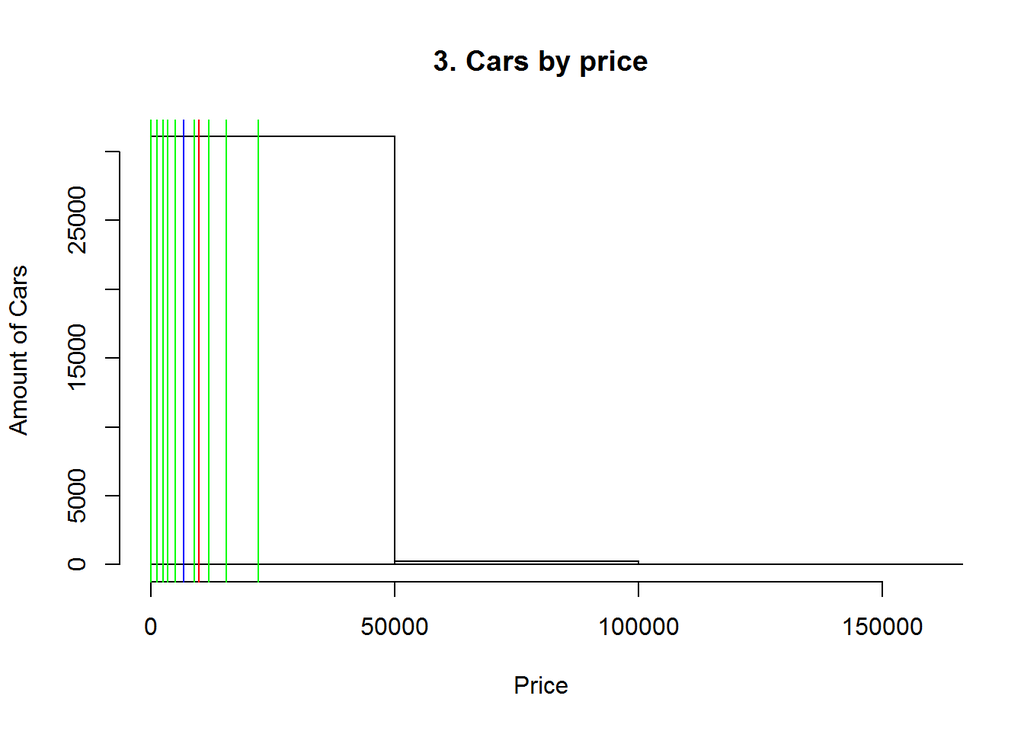

```r
library(lattice)
hist(remove_outliers$price, main = "3. Cars by price", xlim = c(0, 160000),
     xlab = "Price", ylab = "Amount of Cars")
abline(v = remove_outliers_mean, col = "red") #mean is in RED
abline(v = remove_outliers_quant, col = "green") #deciles is in GREEN
abline(v = remove_outliers_median, col = "blue") #median is in BLUE
```

```r
remove_outliers_2 = subset(vposts, vposts$price < 60000) #make a subset of prices less than 60000 and set it to remove_outliers_2
c3 = remove_outliers_2$price
remove_outliers_mean2 = mean(c3, na.rm = TRUE) #mean
remove_outliers_mean2
```

```
## [1] 9429.916
```

```r
remove_outliers_quant2 = quantile(c3, prob = seq(0, 1, .1),
      na.rm = TRUE) #deciles
remove_outliers_quant2
```

```
##      0%     10%     20%     30%     40%     50%     60%     70%     80%
##     1.0  1200.0  2495.0  3500.0  4980.0  6500.0  8799.8 11500.0 15000.0
##     90%    100%
## 21787.2 59999.0
```

```r
remove_outliers_median2 = median(c3, na.rm = TRUE) #median
remove_outliers_median2
```

```
## [1] 6500
```

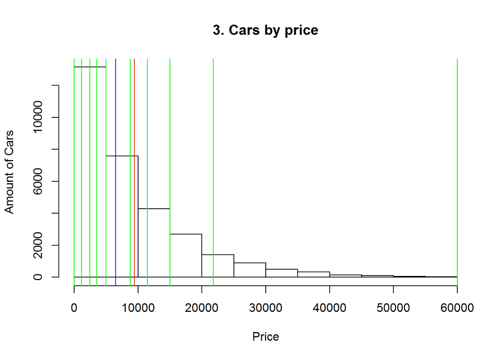

```r
hist(c3, main = "3. Cars by price", xlab = "Price", ylab = "Amount of Cars")
abline(v = remove_outliers_mean2, col = "red") #mean is in RED
abline(v = remove_outliers_quant2, col = "green") #deciles is in GREEN
abline(v = remove_outliers_median2, col = "blue") #median is in BLUE
```

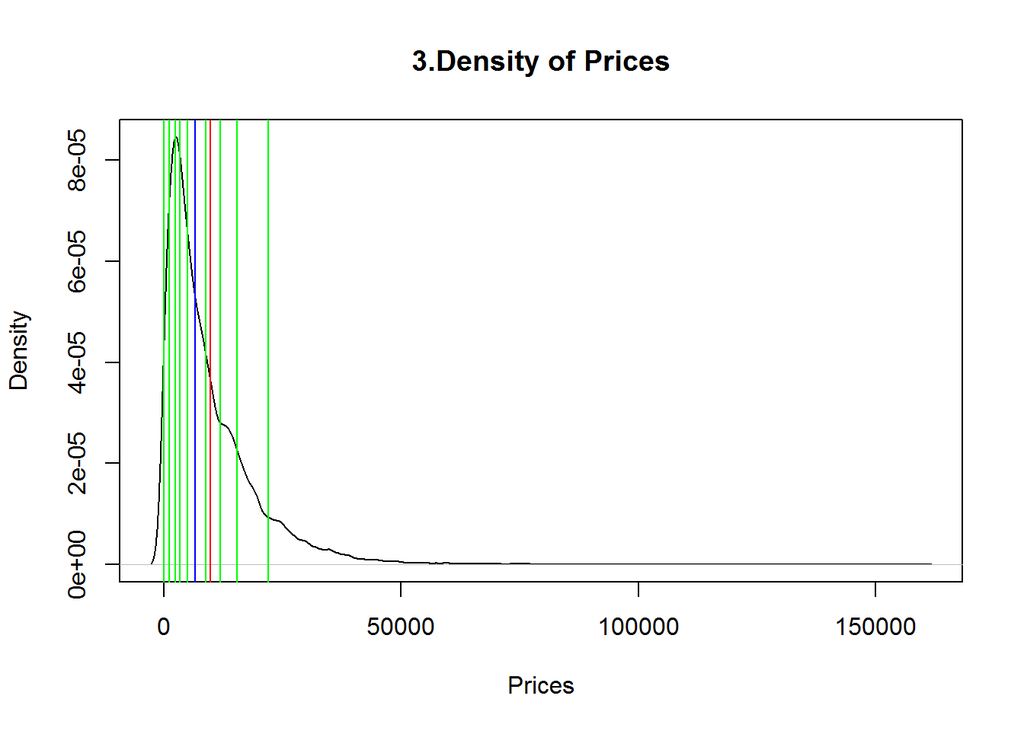

```r
plot(density(vposts$price[vposts$price < 160000], na.rm = TRUE), main =
      "3.Density of Prices", xlab = "Prices")
abline(v = remove_outliers_mean, col = "red") #mean is in RED
abline(v = remove_outliers_quant, col = "green") #deciles is in GREEN
abline(v = remove_outliers_median, col = "blue") #median is in BLUE
```

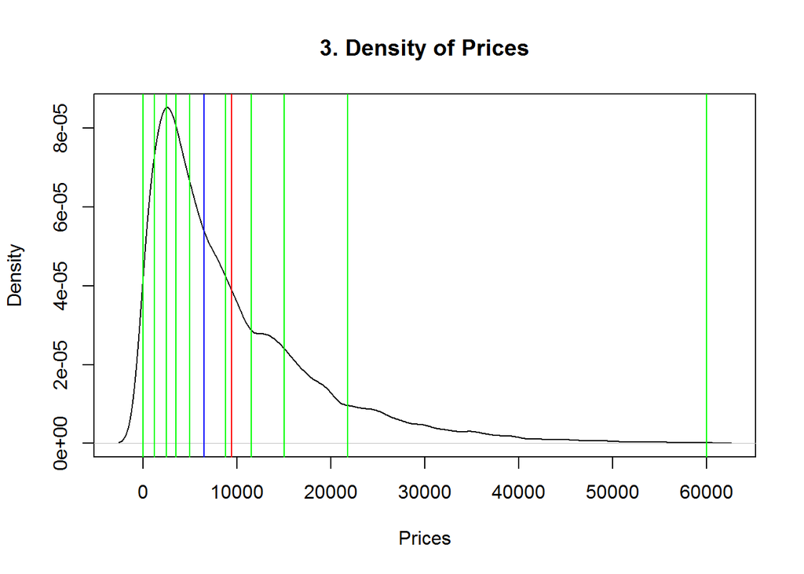

```r
plot(density(vposts$price[vposts$price < 60000], na.rm = TRUE), main =
      "3. Density of Prices", xlab = "Prices")
abline(v = remove_outliers_mean2, col = "red") #mean is in RED
abline(v = remove_outliers_quant2, col = "green") #deciles is in GREEN
abline(v = remove_outliers_median2, col = "blue") #median is in BLUE
```

Many of the vehicles are priced between $0 to $20000. The plot is skewed right and most of the vehicles are prices between $0 and $20000.

### 4. What are the different categories of vehicles, i.e. the type variable/column? What is the proportion for each category?

```r
levels(vposts$type) #categories of vehicles
```

```
##  [1] "bus"         "convertible" "coupe"       "hatchback"   "mini-van"
##  [6] "offroad"     "other"       "pickup"      "sedan"       "SUV"
## [11] "truck"       "van"         "wagon"
```

The categories of vehcnicles are bus, convertable, coupe, hatchback, mini-van, offroad, other, pickup, sedan, SUV, truck, van, and wagon.

```r
table(vposts$type) #proportion of each category
```

```
##
##         bus convertible       coupe   hatchback    mini-van     offroad
##          22         706        1626         819         453          66
##       other      pickup       sedan         SUV       truck         van
##         666         909        7040        4211        1202         507
##       wagon
##         558
```

```r
sum(is.na(vposts$type)) #number of NAs
```

```
## [1] 15892
```

The total number of NAs are 15892.

```r
nrow(vposts) #total rows in data frame
```

```
## [1] 34677
```

```r
# The total rows in the data frame is 34677.
```

The proportions for each vehicle type are:

```r
library(gmodels)
CrossTable(vposts$type) #find proportion of each type of vehicles
```

```
##
##
##    Cell Contents
## |-------------------------|
## |                       N |
## |         N / Table Total |
## |-------------------------|
##
##
## Total Observations in Table:  18785
##
##
##             |         bus | convertible |       coupe |   hatchback |    mini-van |
##             |-------------|-------------|-------------|-------------|-------------|
##             |          22 |         706 |        1626 |         819 |         453 |
##             |       0.001 |       0.038 |       0.087 |       0.044 |       0.024 |
##             |-------------|-------------|-------------|-------------|-------------|
##
##
##             |     offroad |       other |      pickup |       sedan |         SUV |
##             |-------------|-------------|-------------|-------------|-------------|
##             |          66 |         666 |         909 |        7040 |        4211 |
##             |       0.004 |       0.035 |       0.048 |       0.375 |       0.224 |
##             |-------------|-------------|-------------|-------------|-------------|
##
##
##             |       truck |         van |       wagon |
##             |-------------|-------------|-------------|
##             |        1202 |         507 |         558 |
##             |       0.064 |       0.027 |       0.030 |
##             |-------------|-------------|-------------|
##
##
##
##
```

The NAs are not included because we do not know what type of vehicle it is, so the data for NA vehicle type is meaningless; however, the proportion of NA vehicle type is 15892/34677 = 0.458

### 5. Display the relationship between fuel type and vehicle type. Does this depend on transmission type?

```r
levels(vposts$transmission)
```

```
## [1] "automatic" "manual"    "other"
```

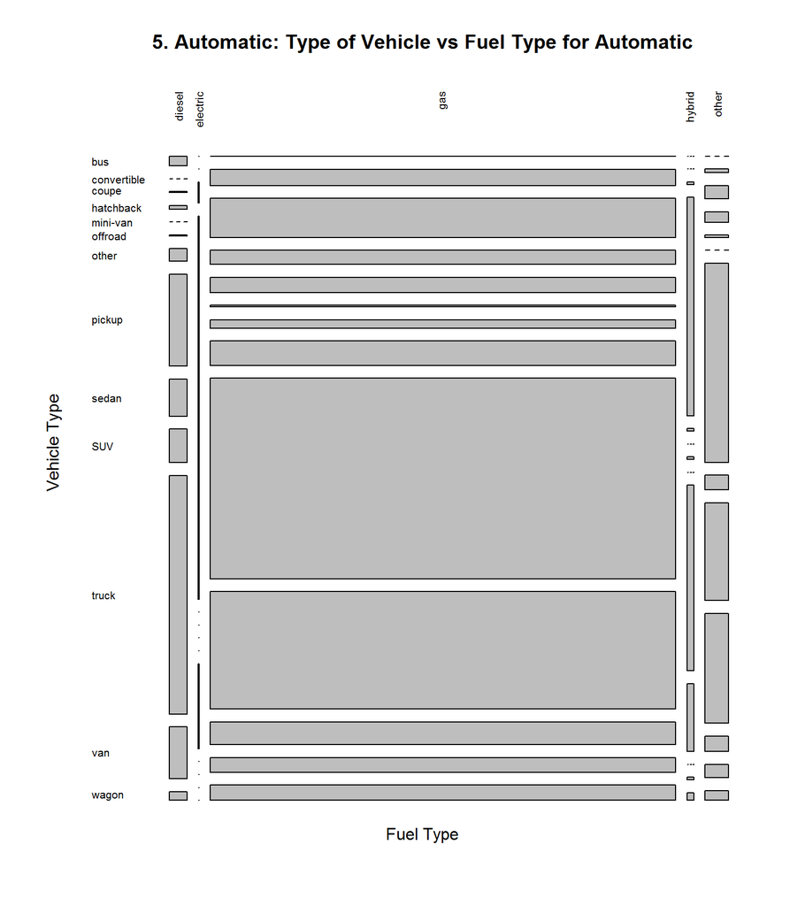

```r
bytrans = split(vposts, vposts$transmission)
by_trans_table = lapply(bytrans, function(d) table(d$fuel, d$type))

mosaicplot(by_trans_table$automatic, las = 2, main =
      "5. Automatic: Type of Vehicle vs Fuel Type for Automatic", xlab = "Fuel Type",
      ylab = "Vehicle Type") #Shows the relationship between vehicle type vs fuel type for automatic. transmission
```

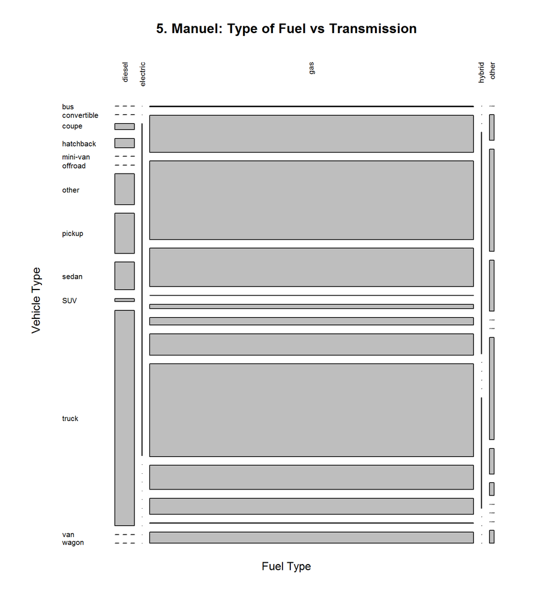

```r
mosaicplot(by_trans_table$manual, las = 2, main =
      "5. Manuel: Type of Fuel vs Transmission", xlab = "Fuel Type",
      ylab = "Vehicle Type") #Shows the relationship between fuel type vs fuel for manual.
```

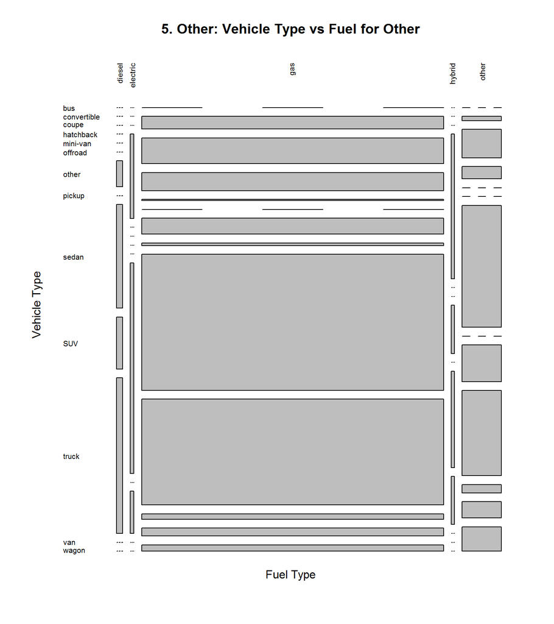

```r
mosaicplot(by_trans_table$other, las = 2, main = "5. Other: Vehicle Type vs Fuel for Other",
      xlab = "Fuel Type", ylab = "Vehicle Type") #shows the relationship between type vs fuel for other.
```

### 6. How many different cities are represented in the dataset?

```r
table(vposts$city) #to see how many cities are in the data.frame vposts
```

```
##
##   boston  chicago   denver lasvegas      nyc      sac    sfbay
##     4958     4886     4979     4963     4983     4966     4942
```

There are 7 cities represented in the dataset. They are Boston, Chiago, Denver, Las Vegas, NYC, Sacramento, and SFbay

### 7. Visually display how the number/proportion of “for sale by owner” and “for sale by dealer” varies across city?

```r
table(vposts$byOwner) #to see how many sellers are "by owner" or "by dealer"
```

```
##
## FALSE  TRUE
## 17416 17261
```

The number of cars “for sale by owner” are 17261. The number of cars “for sale by dealer” are 17416.

```r
table(vposts$byOwner)/length(vposts$byOwner)
```

```
##
##     FALSE      TRUE
## 0.5022349 0.4977651
```

The proprotion of cars “for sale by owner” is 0.4977651. The proportion of cars “for sale by dealer” is 0.5022349.

```r
table(vposts$byOwner, vposts$city)
```

```
##
##         boston chicago denver lasvegas  nyc  sac sfbay
##   FALSE   2491    2491   2492     2489 2495 2483  2475
##   TRUE    2467    2395   2487     2474 2488 2483  2467
```

Vehicles that are “for sale by owner” are marked as TRUE and vehicles that are “for sale by dealer” are marked as FALSE.

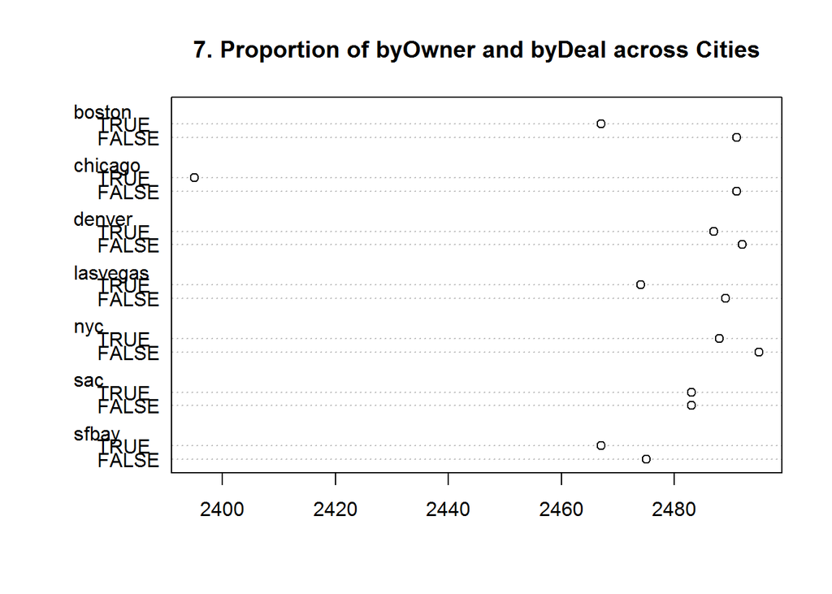

```r
dotchart(as.matrix(table(vposts$byOwner, vposts$city)), main =
      "7. Proportion of byOwner and byDeal across Cities")
```

### 8. What is the largest price for a vehicle in this data set? Examine this and fix the value. Now examine the new highest value for price.

```r
max(vposts$price[vposts$price < max (vposts$price, na.rm = TRUE)],
      na.rm = TRUE) #find largest price for vehicle
```

```
## [1] 30002500
```

```r
sum(vposts$price == 30002500, na.rm = TRUE) #find how many vehicles with the price of 30002500
```

```
## [1] 1
```

There is only 1 vehicle being sold at the price of 30002500.

```r
which(vposts$price == 30002500) #gives the row number with price of 30002500
```

```
## [1] 8140
```

```r
vposts[8140, "price"] = 32500 #change the price of vehicle in row 8140
```

I have changed the price of the vehicle in row 8140 to 32500 because it is an Cadillac Seville SLS so the price is likely a typo.

```r
max(vposts$price[ vposts$price < max (vposts$price, na.rm = TRUE)],
      na.rm = TRUE) #find the NEW largest price for vehicle
```

```
## [1] 9999999
```

### 9. What are the three most common makes of cars in each city for “sale by owner” and for “sale by dealer”? Are they similar or quite different?

Corresponding with Chad Pickering

```r
by_Owner <- subset(vposts, vposts$byOwner==TRUE) #vehicles sold by owner
by_Dealer <- subset(vposts, vposts$byOwner==FALSE) #vehicles sold by dealer

by_Owner_city_maker <- table(by_Owner$maker, by_Owner$city) #sold by owner x-axis = city, y-axis = maker
by_Dealer_city_maker <- table(by_Dealer$maker, by_Dealer$city) # sold by deaker, x-axis = city, y-axis = maker

top3_by_Owner <- function(x)
{
top3_in_order <- order(x, decreasing = TRUE)[1:3] #orders from highest to lowest, and then grabs the top 3
rownames(by_Owner_city_maker)[top3_in_order]
}

top3_by_Dealer <- function(x)
{
top3_in_order <- order(x, decreasing = TRUE)[1:3] #orders from highest to lowest, and then grabs the top 3
rownames(by_Dealer_city_maker)[top3_in_order]
}
```

The three most common makes of cars for each city that are sold by owner are:

```r
#Lists the top 3 makers for each city by owner
apply(by_Owner_city_maker, 2, top3_by_Owner)
```

```
##
##        boston      chicago     denver      lasvegas    nyc
##   [1,] "ford"      "chevrolet" "ford"      "ford"      "nissan"
##   [2,] "honda"     "ford"      "chevrolet" "chevrolet" "toyota"
##   [3,] "chevrolet" "honda"     "toyota"    "toyota"    "honda"
##
##        sac         sfbay
##   [1,] "toyota"    "toyota"
##   [2,] "ford"      "honda"
##   [3,] "chevrolet" "ford"
```

The three most common makes of cars for each city that are sold by dealer are:

```r
#Lists the top 3 makers for each city by dealer
apply(by_Dealer_city_maker, 2, top3_by_Dealer)
```

```
##
##        boston      chicago     denver      lasvegas    nyc
##   [1,] "ford"      "chevrolet" "ford"      "ford"      "nissan"
##   [2,] "toyota"    "ford"      "chevrolet" "nissan"    "toyota"
##   [3,] "chevrolet" "nissan"    "dodge"     "chevrolet" "honda"
##
##        sac         sfbay
##   [1,] "ford"      "toyota"
##   [2,] "toyota"    "ford"
##   [3,] "chevrolet" "bmw"
```

The three common makers of cars that are “for sale by owner” are not the same throughout the cities. The most common two types of vehicles are Ford and Toyota. The three common makers of cars that are “for sale by dealer” are not all the same throughout the cities. The most common type of vehicle sold is Ford.

### 10. Visually compare the distribution of the age of cars for different cities and for “sale by owner” and “sale by dealer”. Provide an interpretation of the plots, i.e., what are the key conclusions and insights?

```r
sort(table(vposts$year), decreasing = TRUE) #sort and find any years that are over 2016 or smaller than 100
```

[output not shown]

There is 1 vehicle with the year 2022, and 1 vehicle with the year 4.

```r
which(vposts$year == 2022) #find the row that vehicle year 2022 is in
```

```
## [1] 21975
```

```r
vposts[21975, "year"] = 2002 #change the year of vehicle from 2022 to 2002
```

The vehicle year were changed because the newest car can only be year 2016 so year 2022 is not a possible age.

```r
which(vposts$year == 4) #find the row that vehicle year 4 is in
```

```
## [1] 8417
```

```r
vposts[8417,]
```

[output not shown]

After examining the information for the column of year ‘4’, there was not information about what year the vehicle was, nor does it say that it is “4 years old”. Since it says “4” under the year, I’m going to change the year to “2004”.

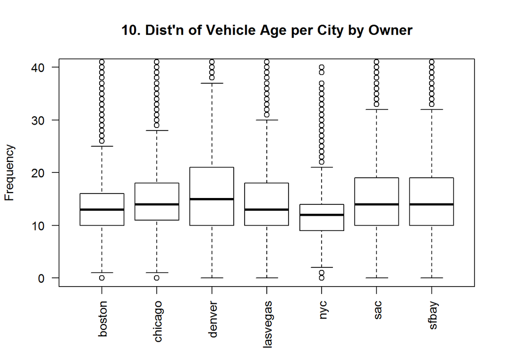

```r
vposts[8417, "year"] = 2004 #change the year of the vehicle from 4 to 2004

# Corresponded with Chad Pickering
vposts$ageOfVehicle <- 2016 - vposts$year #makes a new vector of data and appending it   to vposts
by_Owner <- subset(vposts, byOwner == TRUE)
by_Dealer <- subset(vposts, byOwner == FALSE)

plot(by_Owner$city, by_Owner$ageOfVehicle, main =
      "10. Dist'n of Vehicle Age per City by Owner",
      ylab="Frequency", ylim=c(0,40), las=2)
```

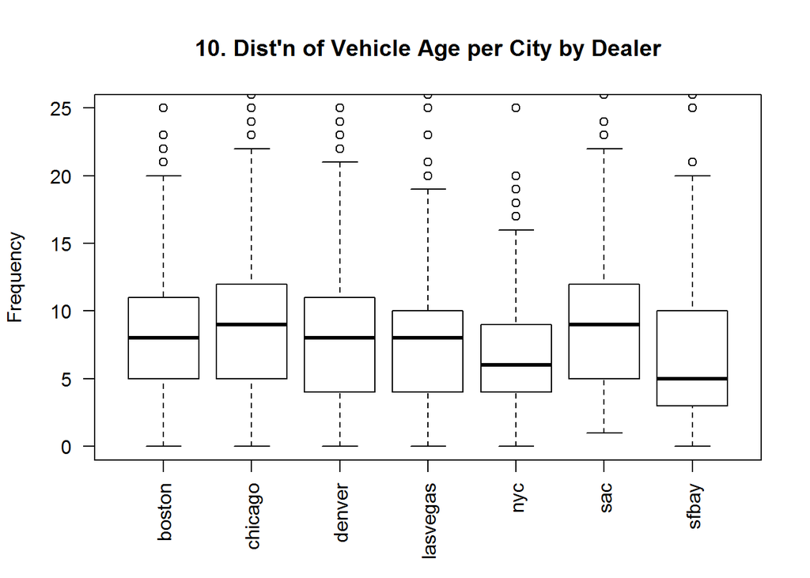

```r
plot(by_Dealer$city, by_Dealer$ageOfVehicle, main =
      "10. Dist'n of Vehicle Age per City by Dealer", ylab="Frequency",
      ylim=c(0,25), las=2)
```

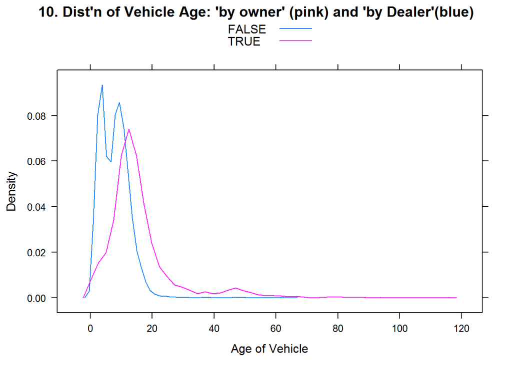

```r
library(lattice)
densityplot( ~ ageOfVehicle, vposts, group = byOwner, plot.points = FALSE, xlab = "Age of Vehicle",
      main = "10. Dist'n of Vehicle Age: 'by owner' (pink) and 'by Dealer'(blue)",
      auto.key = TRUE)
```

Most new vehicles are being sold by dealer and more older vehicles are being sold by owner. This makes sense since dealers generally carry newer and the latest models of vehicles.

### 11. Plot the locations of the posts on a map? What do you notice?

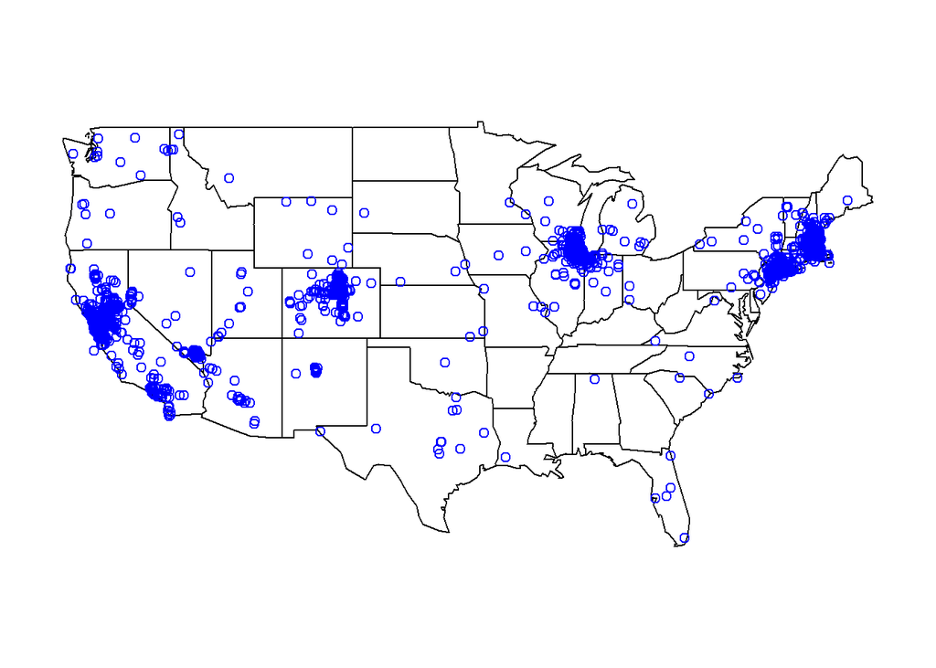

```r
library(maps)
map("state")
points(vposts$long, vposts$lat, col = "blue")
```

```r
#smoothscatter(vposts$lat, vposts$long, add = TRUE)
```

The data appears to be coming from 6 locations even though there are 7 locations in the data set. The locations are mostly clustered in large/highly populated cities.

### 12. Summarize the distribution of fuel type, drive, transmission, and vehicle type. Find a good way to display this information.

Worked with Hannah Kosinovsky and Sierra Tevlin

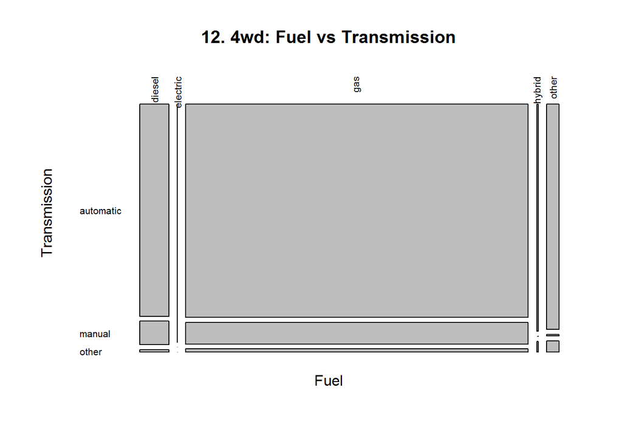

```r
diff_drive = split(vposts, vposts$drive)
by_drive = lapply(diff_drive, function(d) table(d$fuel, d$transmission))
mosaicplot(by_drive$`4wd`, las = 2, main = "12. 4wd: Fuel vs Transmission",
      xlab = "Fuel", ylab = "Transmission")
```

Majority of 4wd vehicles run on gas as fuel and has an automatic transmission.

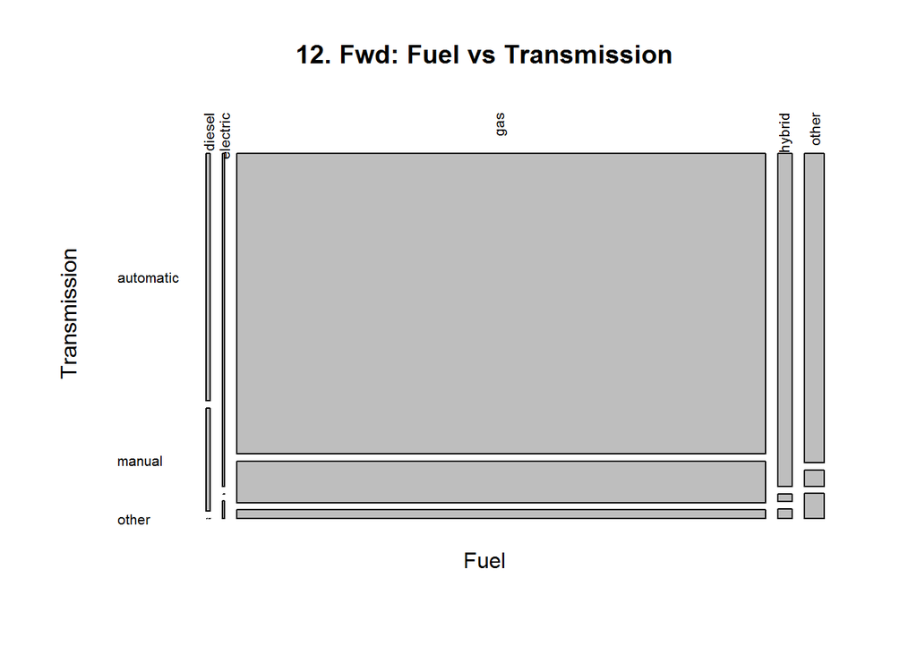

```r
mosaicplot(by_drive$fwd, las = 2, main = "12. Fwd: Fuel vs Transmission",
      xlab = "Fuel", ylab = "Transmission")
```

Majority of fwd vehicles uses gas as fuel and have a an automatic transmission.

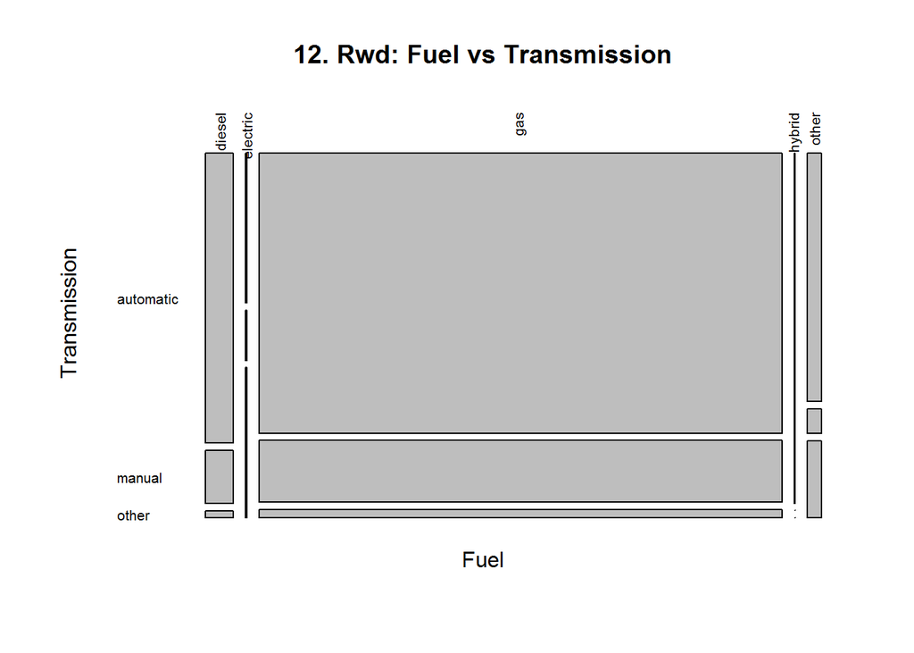

```r
mosaicplot(by_drive$rwd, las = 2, main = "12. Rwd: Fuel vs Transmission",
      xlab = "Fuel", ylab = "Transmission")
```

Majority of rwd vehicles uses gas a fuel and have an automatic transmission

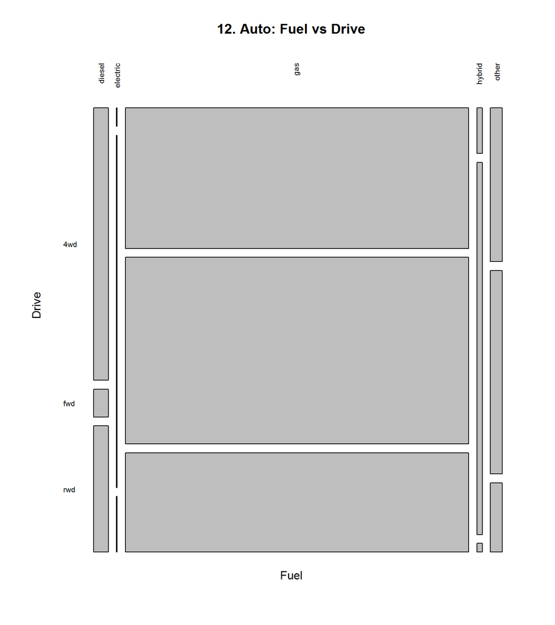

```r
diff_trans = split(vposts, vposts$transmission)
by_transmission = lapply(diff_trans, function(d) table(d$fuel, d$drive))
mosaicplot(by_transmission$automatic, las = 2, main = "12. Auto: Fuel vs Drive",
      xlab = "Fuel", ylab = "Drive")
```

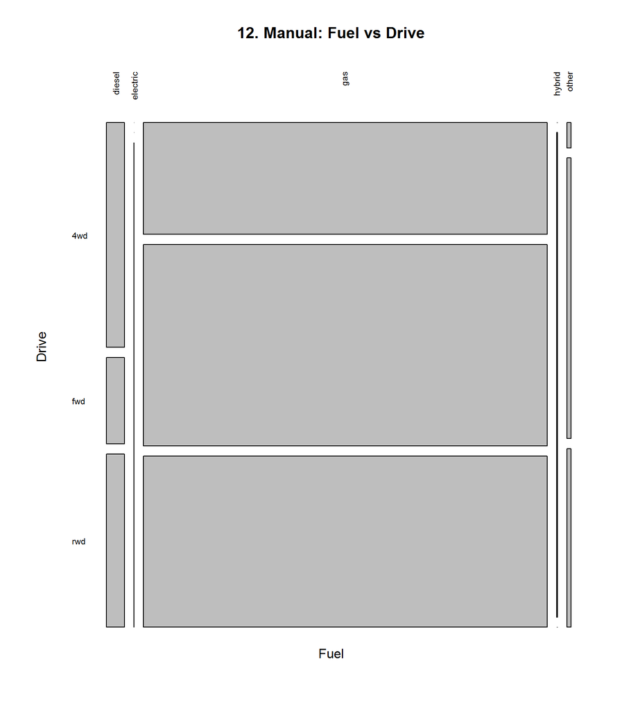

```r
mosaicplot(by_transmission$manual, las = 2, main = "12. Manual: Fuel vs Drive",
      xlab = "Fuel", ylab = "Drive")
```

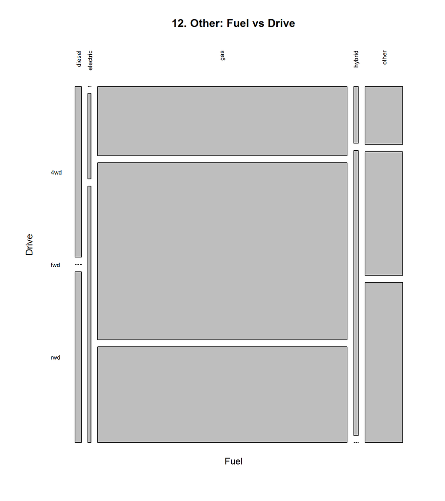

```r
mosaicplot(by_transmission$other, las = 2, main = "12. Other: Fuel vs Drive",
      xlab = "Fuel", ylab = "Drive")
```

### 13. Plot odometer reading and age of car? Is there a relationship? Similarly, plot odometer reading and price? Interpret the result(s). Are odometer reading and age of car related?

Corresponding with Chad Pickering

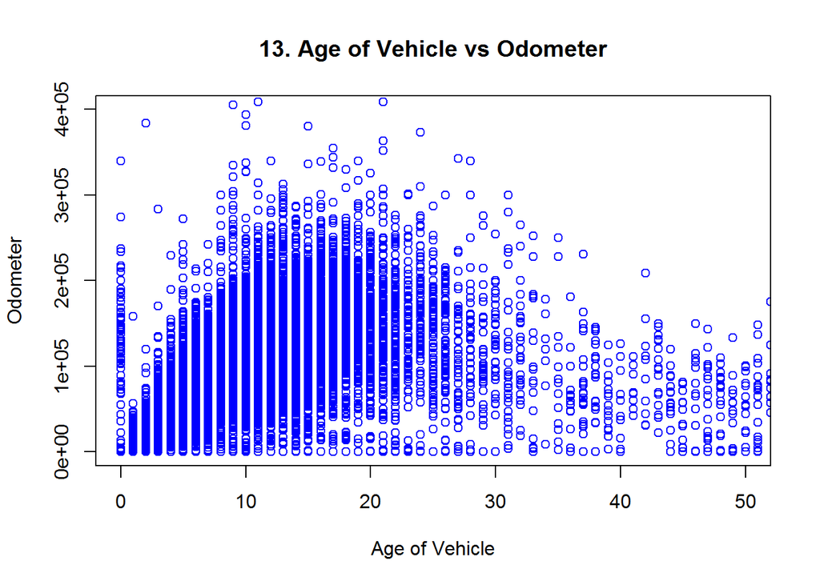

```r
plot(vposts$ageOfVehicle, vposts$odometer, xlim = c(0, 50), ylim = c(0, 4e+05),
      main = "13. Age of Vehicle vs Odometer", xlab = "Age of Vehicle",
      ylab = "Odometer", col = "blue") #plots year vs odometer (milage)
```

The newer the vehicle, the less milage (odometer) it has.

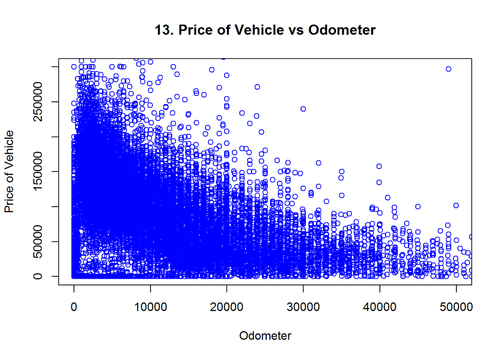

```r
plot(vposts$price, vposts$odometer, xlim = c(0e+00, 50000), ylim = c(0.0e+00, 3e+05),
      main = "13. Price of Vehicle vs Odometer", xlab = "Odometer",
      ylab = "Price of Vehicle", col = "blue") #plots price vs odometer (milage)
```

I zoomed in on the x and y axis so that it omitted outliers so I can get a better view of the distributions. It shows that the less milage (odometer) a vehicle has, the more expensive it is.

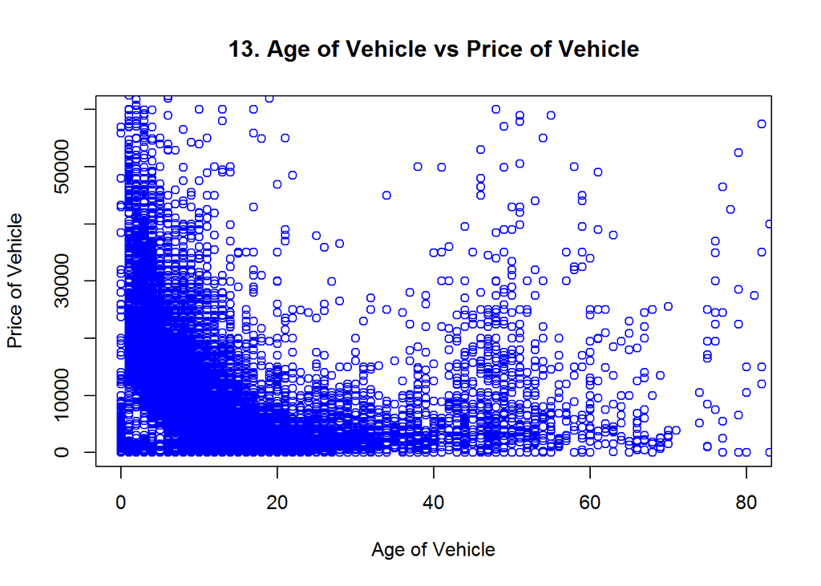

```r
#year/age(looks nice) and price
plot(vposts$ageOfVehicle, vposts$price, xlim = c(0, 80), ylim = c(0, 60000),
      main = "13. Age of Vehicle vs Price of Vehicle", xlab = "Age of Vehicle",
      ylab = "Price of Vehicle", col = "blue")
```

Here, I also zoomed in due to outliers that were making the distributions hard to see. It shows that vehicles with ages 30 or younger have a higher cost. The newer the vehicle (smaller age) cost more.

### 14. Identify the “old” cars. What manufacturers made these? What is the price distribution for these?

Corresponding with Chad Pickering I dentify old cars as any year from 1999 and earlier or with an odometer of 240000 or higher.

```r
old_cars = vposts[(vposts$year < 2000) | (vposts$odometer >= 240000),] #takes all the vehicle year earlier than 2000 or with an odometer of 240000 or more as my definition of an "old car", comma means I want all of columns
```

```r
unique(vposts$maker) #see how many different makers of vehicles
```

[output not shown]

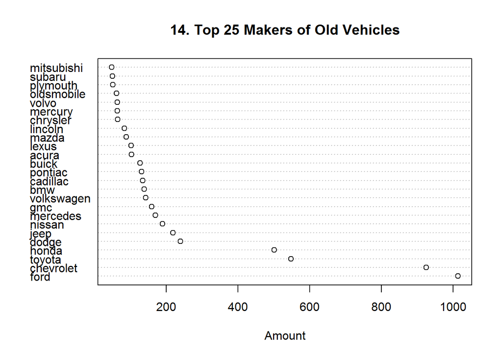

```r
dotchart(head(sort(table(old_cars$maker), decreasing = TRUE), 25),
      main = "14. Top 25 Makers of Old Vehicles", xlab = "Amount") #shows tops 25 makers of old vehicles
```

Since there are 73 makers, I took only the top 25 makers that have the the most amount of vehicles in our data set.

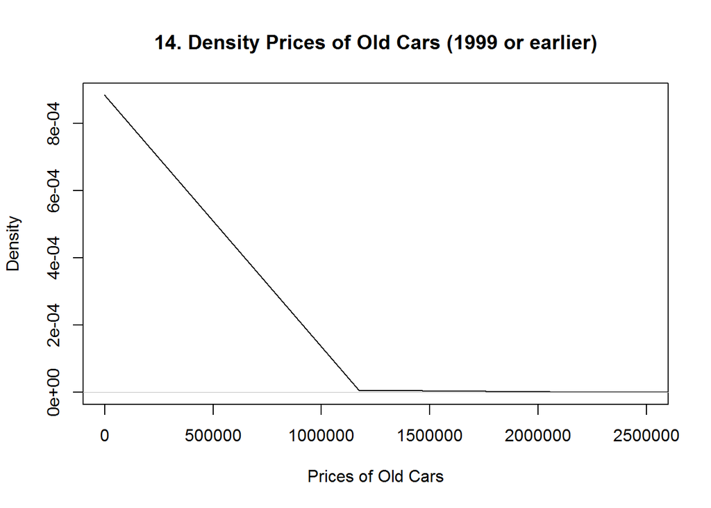

```r
library(lattice)
plot(density(old_cars$price, na.rm = TRUE),xlim = c(0,2500000),
      main = "14. Density Prices of Old Cars (1999 or earlier)",
      xlab = "Prices of Old Cars")
```

There are high amounts of vehicles that are being sold at 1000000 or less.

### 15. I have omitted one important variable in this data set. What do you think it is? Can we derive this from the other variables? If so, sketch possible ideas as to how we would compute this variable.

Corresponding with Chad Pickering

```r
vposts[1, ] #Take a look at column names to see if there are any columns that are currently present but are not listed when we do vposts$

# I noticed header has some information that could be made into a seperate column
vposts$header
```

I noticed that header consists of “year maker model”; however model is not a variable listed, so this might be a the missing variable that was omitted. We can parse the model. For example, if the header is “2001 Ford F-150” we can parse out “F-150” and make it a seperate variable called “model”.

### 16. Display how condition and odometer are related. Also how condition and price are related. And condition and age of the car. Provide a brief interpretation of what you find.

Corresponding with Chad Pickering

```r
condition_odo = split(vposts$odometer, vposts$condition)
```

```r
levels(vposts$condition) #to see which categories I want to be shown on the boxplot
```

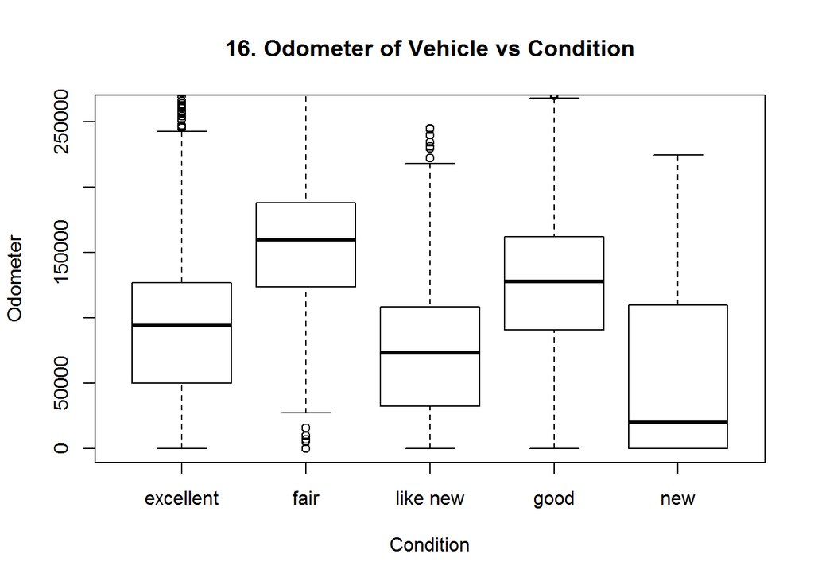

```r
boxplot(condition_odo[c(7, 8, 13, 10, 22)], condition_odo, ylim = c(0, 260000),
      main = "16. Odometer of Vehicle vs Condition", xlab = "Condition",
      ylab = "Odometer")
```

I “zoomed in” because outliers skewing the distributions of the boxplots, making it difficult to see. The odometer readings are between 0 and 260000. The lower the odometer, the better the condition of the vehicle. “New” and “like new” vehicles have the lowest odometer readings.

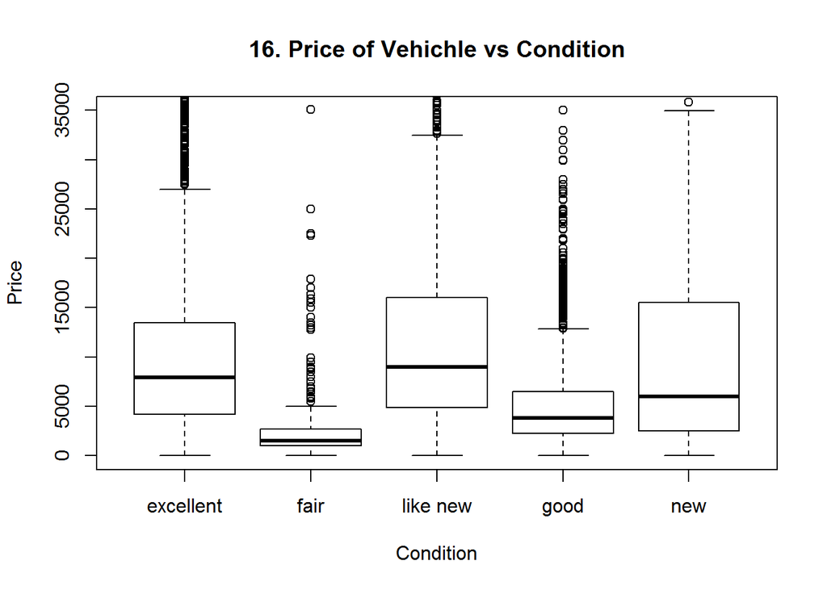

```r
condition_price = split(vposts$price, vposts$condition)
boxplot(condition_price[c(7, 8, 13, 10, 22)], condition_price, ylim = c(0, 35000),
      main = "16. Price of Vehichle vs Condition", xlab = "Condition", ylab = "Price")
```

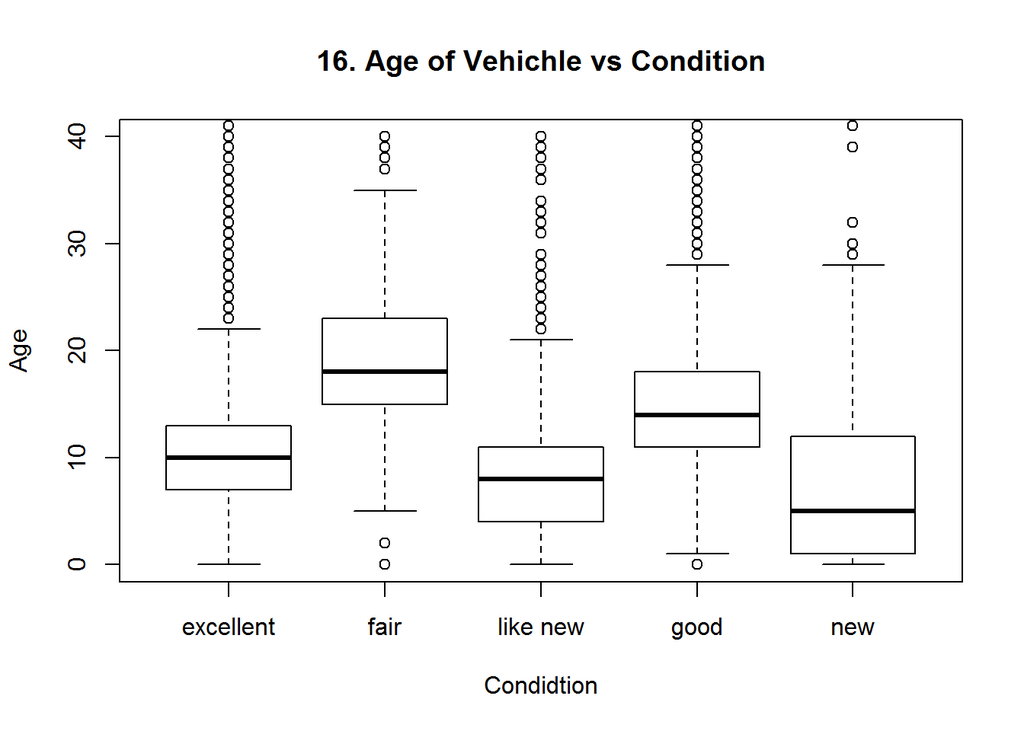

```r
condition_year = split(vposts$ageOfVehicle, vposts$condition)
boxplot(condition_year[c(7, 8, 13, 10, 22)], condition_price, ylim = c(0, 40),
     main = "16. Age of Vehichle vs Condition", xlab = "Condidtion", ylab = "Age")
```

### Code Appendix

```r
print(load(url("http://eeyore.ucdavis.edu/stat141/Data/vehicles.rda")))

lty = c(3, 4, 5) #changes the line types (dotted, dashed, etc)
# ~odometer means you want odometer on the x-axis,
# how to add more than one line in a density plot

#plots multiple lines on a density plot
table(vposts$transmission)
library(lattice)
densityplot(~odometer, vposts, group = transmission, plot.points = FALSE, xlim = c(0, 50000), auto.key = TRUE)
nrow(vposts)
names(vposts)
lapply(vposts, class)
c <- vposts$price #assign vposts$price to c
mean_price = mean(c, na.rm = TRUE) #mean
mean_price
median_price = median(c, na.rm = TRUE) #median
median_price
quant_price = quantile(c, prob = seq(0, 1, .1), na.rm = TRUE) #decile
quant_price

hist(vposts$price, main = "3. Cars by price", xlab = "Price", ylab = "Amount of Cars")
abline(v = mean_price, col = "red") #mean is in RED
abline(v = median_price, col = "blue") #median is in BLUE
abline(v = quant_price, col = "green") #deciles are in GREEN
head(sort(vposts$price, decreasing = TRUE)) #look for outliers
remove_outliers = subset(vposts, vposts$price < 600000) #make a subset without the outliers
c2 = remove_outliers$price #sets remove_outliers$price to c2
remove_outliers_mean = mean(c2, na.rm = TRUE) #find mean
remove_outliers_mean
remove_outliers_quant = quantile(c2, prob = seq(0, 1, .1), na.rm = TRUE) #find deciles
remove_outliers_quant
remove_outliers_median = median(c2, na.rm = TRUE) #find median
remove_outliers_median

library(lattice)
hist(remove_outliers$price, main = "3. Cars by price", xlim = c(0, 160000),
     xlab = "Price", ylab = "Amount of Cars")
abline(v = remove_outliers_mean, col = "red") #mean is in RED
abline(v = remove_outliers_quant, col = "green") #deciles is in GREEN
abline(v = remove_outliers_median, col = "blue") #median is in BLUE
remove_outliers_2 = subset(vposts, vposts$price < 60000) #make a subset of prices less than 60000 and set it to remove_outliers_2
c3 = remove_outliers_2$price
remove_outliers_mean2 = mean(c3, na.rm = TRUE) #mean
remove_outliers_mean2
remove_outliers_quant2 = quantile(c3, prob = seq(0, 1, .1),
      na.rm = TRUE) #deciles
remove_outliers_quant2
remove_outliers_median2 = median(c3, na.rm = TRUE) #median
remove_outliers_median2

hist(c3, main = "3. Cars by price", xlab = "Price", ylab = "Amount of Cars")
abline(v = remove_outliers_mean2, col = "red") #mean is in RED
abline(v = remove_outliers_quant2, col = "green") #deciles is in GREEN
abline(v = remove_outliers_median2, col = "blue") #median is in BLUE
plot(density(vposts$price[vposts$price < 160000], na.rm = TRUE), main =
      "3.Density of Prices", xlab = "Prices")
abline(v = remove_outliers_mean, col = "red") #mean is in RED
abline(v = remove_outliers_quant, col = "green") #deciles is in GREEN
abline(v = remove_outliers_median, col = "blue") #median is in BLUE
plot(density(vposts$price[vposts$price < 60000], na.rm = TRUE), main =
      "3. Density of Prices", xlab = "Prices")
abline(v = remove_outliers_mean2, col = "red") #mean is in RED
abline(v = remove_outliers_quant2, col = "green") #deciles is in GREEN
abline(v = remove_outliers_median2, col = "blue") #median is in BLUE
levels(vposts$type) #categories of vehicles
table(vposts$type) #proportion of each category

sum(is.na(vposts$type)) #number of NAs
nrow(vposts) #total rows in data frame
# The total rows in the data frame is 34677.
library(gmodels)
CrossTable(vposts$type) #find proportion of each type of vehicles
levels(vposts$transmission)
bytrans = split(vposts, vposts$transmission)
by_trans_table = lapply(bytrans, function(d) table(d$fuel, d$type))

mosaicplot(by_trans_table$automatic, las = 2, main =
      "5. Automatic: Type of Vehicle vs Fuel Type for Automatic", xlab = "Fuel Type",
      ylab = "Vehicle Type") #Shows the relationship between vehicle type vs fuel type for automatic. transmission
mosaicplot(by_trans_table$manual, las = 2, main =
      "5. Manuel: Type of Fuel vs Transmission", xlab = "Fuel Type",
      ylab = "Vehicle Type") #Shows the relationship between fuel type vs fuel for manual.
mosaicplot(by_trans_table$other, las = 2, main = "5. Other: Vehicle Type vs Fuel for Other",
      xlab = "Fuel Type", ylab = "Vehicle Type") #shows the relationship between type vs fuel for other.
table(vposts$city) #to see how many cities are in the data.frame vposts
table(vposts$byOwner) #to see how many sellers are "by owner" or "by dealer"
table(vposts$byOwner)/length(vposts$byOwner)
table(vposts$byOwner, vposts$city)
dotchart(as.matrix(table(vposts$byOwner, vposts$city)), main =
      "7. Proportion of byOwner and byDeal across Cities")
max(vposts$price[vposts$price < max (vposts$price, na.rm = TRUE)],
      na.rm = TRUE) #find largest price for vehicle
sum(vposts$price == 30002500, na.rm = TRUE) #find how many vehicles with the price of 30002500
which(vposts$price == 30002500) #gives the row number with price of 30002500
vposts[8140, "price"] = 32500 #change the price of vehicle in row 8140
max(vposts$price[ vposts$price < max (vposts$price, na.rm = TRUE)],
      na.rm = TRUE) #find the NEW largest price for vehicle
by_Owner <- subset(vposts, vposts$byOwner==TRUE) #vehicles sold by owner
by_Dealer <- subset(vposts, vposts$byOwner==FALSE) #vehicles sold by dealer

by_Owner_city_maker <- table(by_Owner$maker, by_Owner$city) #sold by owner x-axis = city, y-axis = maker
by_Dealer_city_maker <- table(by_Dealer$maker, by_Dealer$city) # sold by deaker, x-axis = city, y-axis = maker

top3_by_Owner <- function(x)
{
top3_in_order <- order(x, decreasing = TRUE)[1:3] #orders from highest to lowest, and then grabs the top 3
rownames(by_Owner_city_maker)[top3_in_order]
}

top3_by_Dealer <- function(x)
{
top3_in_order <- order(x, decreasing = TRUE)[1:3] #orders from highest to lowest, and then grabs the top 3
rownames(by_Dealer_city_maker)[top3_in_order]
}
#Lists the top 3 makers for each city by owner
apply(by_Owner_city_maker, 2, top3_by_Owner)
#Lists the top 3 makers for each city by dealer
apply(by_Dealer_city_maker, 2, top3_by_Dealer)
sort(table(vposts$year), decreasing = TRUE) #sort and find any years that are over 2016 or smaller than 100

which(vposts$year == 2022) #find the row that vehicle year 2022 is in
vposts[21975, "year"] = 2002 #change the year of vehicle from 2022 to 2002
which(vposts$year == 4) #find the row that vehicle year 4 is in
vposts[8417,]
vposts[8417, "year"] = 2004 #change the year of the vehicle from 4 to 2004

# Corresponded with Chad Pickering
vposts$ageOfVehicle <- 2016 - vposts$year #makes a new vector of data and appending it   to vposts
by_Owner <- subset(vposts, byOwner == TRUE)
by_Dealer <- subset(vposts, byOwner == FALSE)

plot(by_Owner$city, by_Owner$ageOfVehicle, main =
      "10. Dist'n of Vehicle Age per City by Owner",
      ylab="Frequency", ylim=c(0,40), las=2)
plot(by_Dealer$city, by_Dealer$ageOfVehicle, main =
      "10. Dist'n of Vehicle Age per City by Dealer", ylab="Frequency",
      ylim=c(0,25), las=2)
library(lattice)
densityplot( ~ ageOfVehicle, vposts, group = byOwner, plot.points = FALSE, xlab = "Age of Vehicle",
      main = "10. Dist'n of Vehicle Age: 'by owner' (pink) and 'by Dealer'(blue)",
      auto.key = TRUE)
library(maps)
map("state")
points(vposts$long, vposts$lat, col = "blue")
#smoothscatter(vposts$lat, vposts$long, add = TRUE)
diff_drive = split(vposts, vposts$drive)
by_drive = lapply(diff_drive, function(d) table(d$fuel, d$transmission))
mosaicplot(by_drive$`4wd`, las = 2, main = "12. 4wd: Fuel vs Transmission",
      xlab = "Fuel", ylab = "Transmission")
mosaicplot(by_drive$fwd, las = 2, main = "12. Fwd: Fuel vs Transmission",
      xlab = "Fuel", ylab = "Transmission")
mosaicplot(by_drive$rwd, las = 2, main = "12. Rwd: Fuel vs Transmission",
      xlab = "Fuel", ylab = "Transmission")
diff_trans = split(vposts, vposts$transmission)
by_transmission = lapply(diff_trans, function(d) table(d$fuel, d$drive))
mosaicplot(by_transmission$automatic, las = 2, main = "12. Auto: Fuel vs Drive",
      xlab = "Fuel", ylab = "Drive")
mosaicplot(by_transmission$manual, las = 2, main = "12. Manual: Fuel vs Drive",
      xlab = "Fuel", ylab = "Drive")
mosaicplot(by_transmission$other, las = 2, main = "12. Other: Fuel vs Drive",
      xlab = "Fuel", ylab = "Drive")
plot(vposts$ageOfVehicle, vposts$odometer, xlim = c(0, 50), ylim = c(0, 4e+05),
      main = "13. Age of Vehicle vs Odometer", xlab = "Age of Vehicle",
      ylab = "Odometer", col = "blue") #plots year vs odometer (milage)
plot(vposts$price, vposts$odometer, xlim = c(0e+00, 50000), ylim = c(0.0e+00, 3e+05),
      main = "13. Price of Vehicle vs Odometer", xlab = "Odometer",
      ylab = "Price of Vehicle", col = "blue") #plots price vs odometer (milage)
#year/age(looks nice) and price
plot(vposts$ageOfVehicle, vposts$price, xlim = c(0, 80), ylim = c(0, 60000),
      main = "13. Age of Vehicle vs Price of Vehicle", xlab = "Age of Vehicle",
      ylab = "Price of Vehicle", col = "blue")
old_cars = vposts[(vposts$year < 2000) | (vposts$odometer >= 240000),] #takes all the vehicle year earlier than 2000 or with an odometer of 240000 or more as my definition of an "old car", comma means I want all of columns
unique(vposts$maker) #see how many different makers of vehicles
dotchart(head(sort(table(old_cars$maker), decreasing = TRUE), 25),
      main = "14. Top 25 Makers of Old Vehicles", xlab = "Amount") #shows tops 25 makers of old vehicles
library(lattice)
plot(density(old_cars$price, na.rm = TRUE),xlim = c(0,2500000),
      main = "14. Density Prices of Old Cars (1999 or earlier)",
      xlab = "Prices of Old Cars")
vposts[1, ] #Take a look at column names to see if there are any columns that are currently present but are not listed when we do vposts$

# I noticed header has some information that could be made into a seperate column
vposts$header
condition_odo = split(vposts$odometer, vposts$condition)
levels(vposts$condition) #to see which categories I want to be shown on the boxplot
boxplot(condition_odo[c(7, 8, 13, 10, 22)], condition_odo, ylim = c(0, 260000),
      main = "16. Odometer of Vehicle vs Condition", xlab = "Condition",
      ylab = "Odometer")
condition_price = split(vposts$price, vposts$condition)
boxplot(condition_price[c(7, 8, 13, 10, 22)], condition_price, ylim = c(0, 35000),
      main = "16. Price of Vehichle vs Condition", xlab = "Condition", ylab = "Price")
condition_year = split(vposts$ageOfVehicle, vposts$condition)
boxplot(condition_year[c(7, 8, 13, 10, 22)], condition_price, ylim = c(0, 40),
     main = "16. Age of Vehichle vs Condition", xlab = "Condidtion", ylab = "Age")
```